# Case Study: Oscar Winner Ages

SOLUTIONS // Jill E. Thomley

Sunday, February 16, 2020 @ 06:27 PM

### **NOTE:** I updated some erroneous ages in the dataset betweeen the time we did the class activity and when I compiled the solutions. If you re-run your code you will also have the updated values.

Load the package(s) you will need.

```r
library(tidyverse)
```

In January 2007, Entertainment Weekly magazine featured a [cover story](http://www.simplystreep.com/gallery/displayimage.php?album=345&pid=25019#top_display_media) about three Academy Award nominees for Best Actress (Meryl Streep, Judy Densch, and Helen Mirren), with a cover tagline that proclaimed “The Silver Foxes Rule!” This theme continued inside, with the article focusing in large part on how old these three women were, relative to previous winners, and the perceived Hollywood bias in favor of younger actresses. This discussion persists in one form or another to this day. (data: oscarages.csv)

```r
oscar <- read_csv("https://raw.githubusercontent.com/STAT-JET-ASU/Datasets/master/Instructor/oscarages.csv")
```

2. Use `filter` to create a dataset that contains data only for Best Actor and Best Actress winners prior to the 2007 Academy Awards ceremony. Note that the variable `ceremony` refers to the ceremony year.

There are a few ways to handle the `filter()` statement, since there are multiple criteria. The `dplyr` package contains the `%in%` function, which makes choosing a subset of a variable’s values easy and succinct.

```r
# acceptable
oscarpre2007 <- oscar %>%
  filter(ceremony < 2007, category == "Best Actor" | category == "Best Actress")
```

```r
# acceptable
oscarpre2007 <- oscar %>%
  filter(ceremony < 2007, category != "Supporting Actor", category != "Supporting Actress")
```

```r
# better way
oscarpre2007 <- oscar %>%
  filter(ceremony < 2007, category %in% c("Best Actor", "Best Actress"))
```

3. Use `summarize` (with any other necessary functions) on your new dataset to compute and display the sample sizes, means, standard deviations, five-number summaries, IQR, and the lower and upper fences for Best Actor and Best Actress winners prior to 2007.

After filtering, you have two groups left in the `category` variable: `Best Actor` and `Best Actress`. Use `group_by()` to get separate summaries for the two groups. Once a statistic is computed inside `summarize()`, it can be used in subsequent summaries, like the lower and upper fence calculations below. The `print.data.frame()` function is rounding to four significant digits.

```r
agesumms <- oscarpre2007 %>%
  group_by(category) %>%
  summarize(n       = n(),
            meanAge  = mean(age),
            sdAge    = sd(age),
            minAge   = fivenum(age)[1],
            Q1Age    = fivenum(age)[2],
            medAge   = fivenum(age)[3],
            Q3Age    = fivenum(age)[4],
            maxAge   = fivenum(age)[5],
            iqrAge   = IQR(age),
            lowFence = Q1Age - 1.5 * iqrAge,
            uppFence = Q3Age + 1.5 * iqrAge)
print.data.frame(agesumms, digits = 4)
```

```
      category  n meanAge sdAge minAge Q1Age medAge Q3Age maxAge iqrAge
1   Best Actor 79   43.56  8.92     29  37.0     42  48.5     76   11.5
2 Best Actress 79   35.61 11.28     21  28.5     33  39.0     80   10.5
  lowFence uppFence
1    19.75    65.75
2    12.75    54.75
```

4. Create boxplots to compare the ages of Best Actor and Best Actress winners prior to 2007. Add an informative title, x and y axis labels, a caption that shows the data source, and color in the plots to improve the display.

There are several different ways to handle color in boxplots. One is to specify a `color` or `fill` variable in the aesthetic of the plot, but you may need to suppressed the redundant legend in that case. The other is to specify the colors in `geom_boxplot()`. You can also format aspects of the plot like the outliers (see [the ggplot2 reference page](https://ggplot2.tidyverse.org/reference/geom_boxplot.html) for boxplots).

Below are three examples of boxplots comparing the ages of Best Actor and Best Actress winners. The last graph shows how you can change the presentation to better visualize overlapping outliers and set more desirable labels for the quantitative axis, as well as apply a theme and flip the display of the axes for a horizontal visualization.

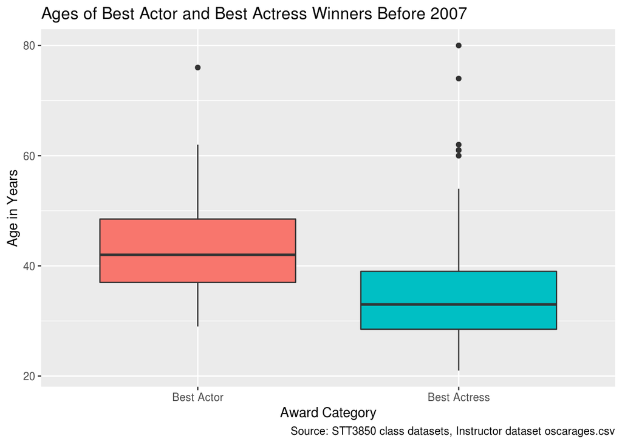

```r
ggplot(oscarpre2007, aes(x = category, y = age, fill = category)) +
  geom_boxplot() +
  labs(title = "Ages of Best Actor and Best Actress Winners Before 2007",
       x = "Award Category",
       y = "Age in Years",
       caption = "Source: STT3850 class datasets, Instructor dataset oscarages.csv") +
  theme(legend.position = "none")
```

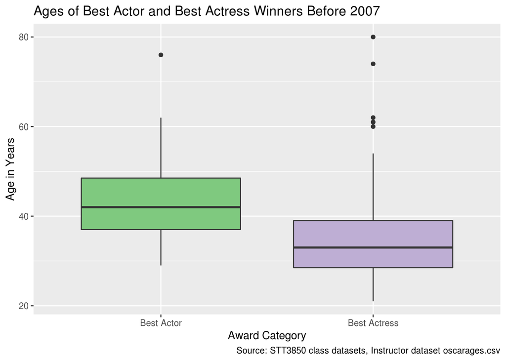

```r
ggplot(oscarpre2007, aes(x = category, y = age, fill = category)) +
  geom_boxplot() +
  scale_fill_brewer(palette = "Accent") +
  labs(title = "Ages of Best Actor and Best Actress Winners Before 2007",
       x = "Award Category",
       y = "Age in Years",
       caption = "Source: STT3850 class datasets, Instructor dataset oscarages.csv") +
  theme(legend.position = "none")
```

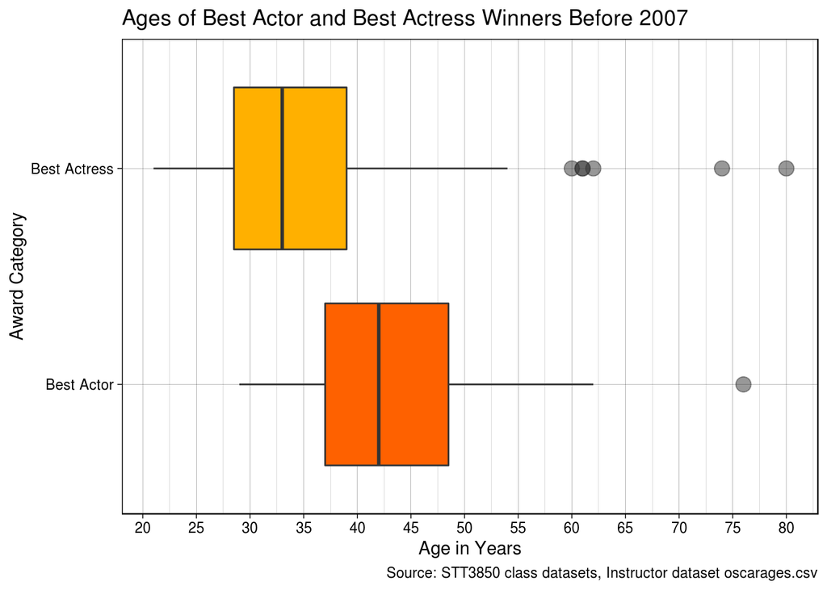

```r
ggplot(oscarpre2007, aes(x = category, y = age)) +
  geom_boxplot(fill = c("#FE6100", "#FFB000"), outlier.size = 4, outlier.alpha = 0.5) +
  scale_y_continuous(breaks = seq(20, 85, 5)) +
  labs(title = "Ages of Best Actor and Best Actress Winners Before 2007",
       x = "Award Category",
       y = "Age in Years",
       caption = "Source: STT3850 class datasets, Instructor dataset oscarages.csv") +
  theme_linedraw() +
  coord_flip()
```

**Note:** The colors in the plots above were chosen to be color-blind friendly. You can read more about color-blind safe palettes and using colors in plots at the links below.

- https://davidmathlogic.com/colorblind/#%23D81B60-%231E88E5-%23FFC107-%23004D40
- http://www.cookbook-r.com/Graphs/Colors_(ggplot2)/
- https://www.datanovia.com/en/blog/the-a-z-of-rcolorbrewer-palette/
5. Use `facet_grid` create histograms to compare the age distributions of Best Actor and Best Actress winners prior to 2007. Arrange the plots so they are stacked versus side-by-side. Add an informative title, x and y axis labels, a caption that shows the data source.

As with boxplots, there are several ways to create histograms to compare the distributions of the two groups. The last shows how you can customize the quantitative axis and one way to use colors.

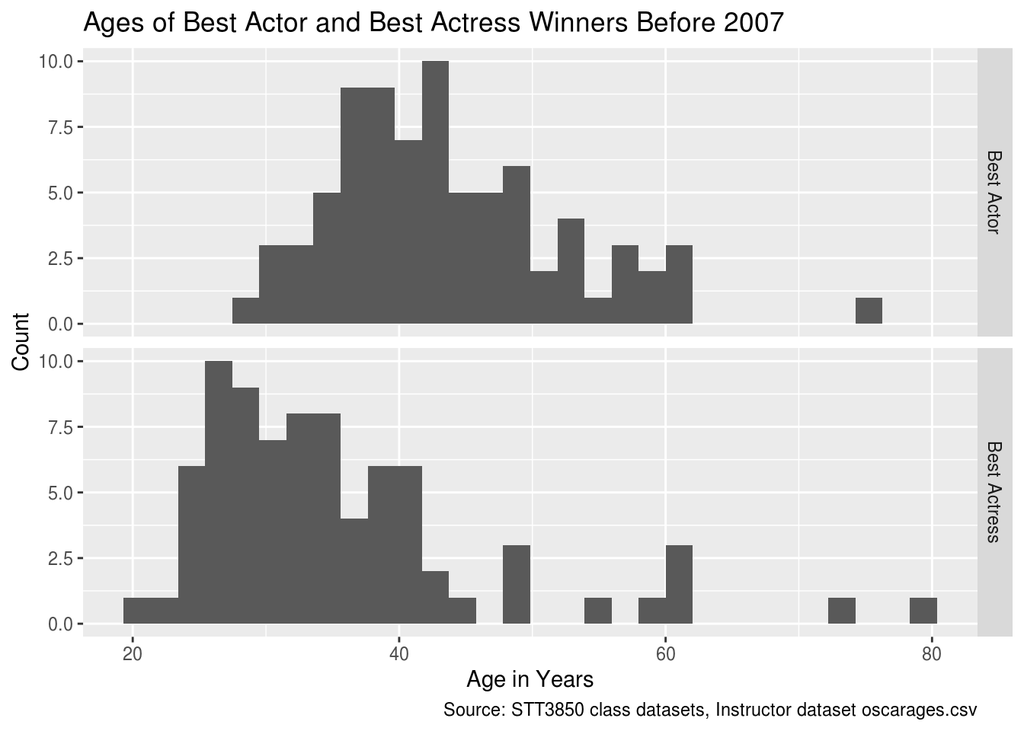

```r
ggplot(oscarpre2007, aes(x = age)) +
  geom_histogram() +
  facet_grid(category ~ .) +
  labs(title = "Ages of Best Actor and Best Actress Winners Before 2007",
       x = "Age in Years",
       y = "Count",
       caption = "Source: STT3850 class datasets, Instructor dataset oscarages.csv")
```

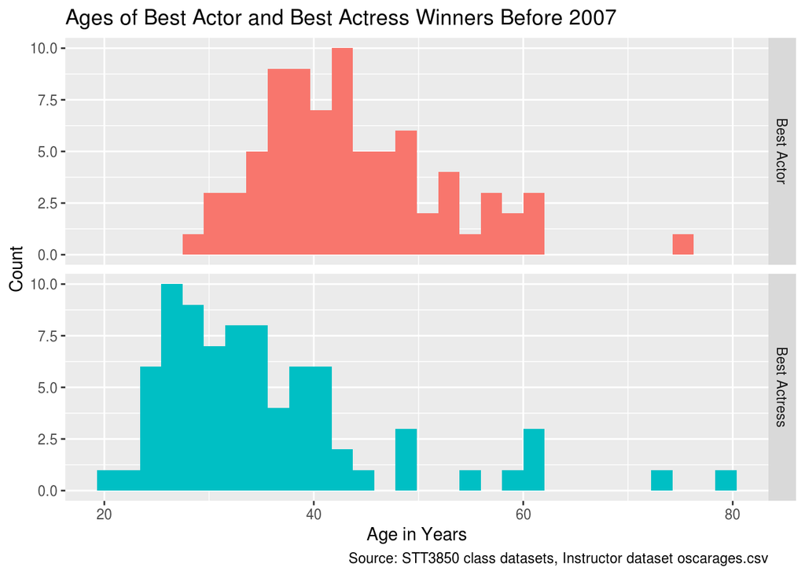

```r
ggplot(oscarpre2007, aes(x = age, fill = category)) +
  geom_histogram() +
  facet_grid(category ~ .) +
  labs(title = "Ages of Best Actor and Best Actress Winners Before 2007",
       x = "Age in Years",
       y = "Count",
       caption = "Source: STT3850 class datasets, Instructor dataset oscarages.csv") +
  theme(legend.position = "none")
```

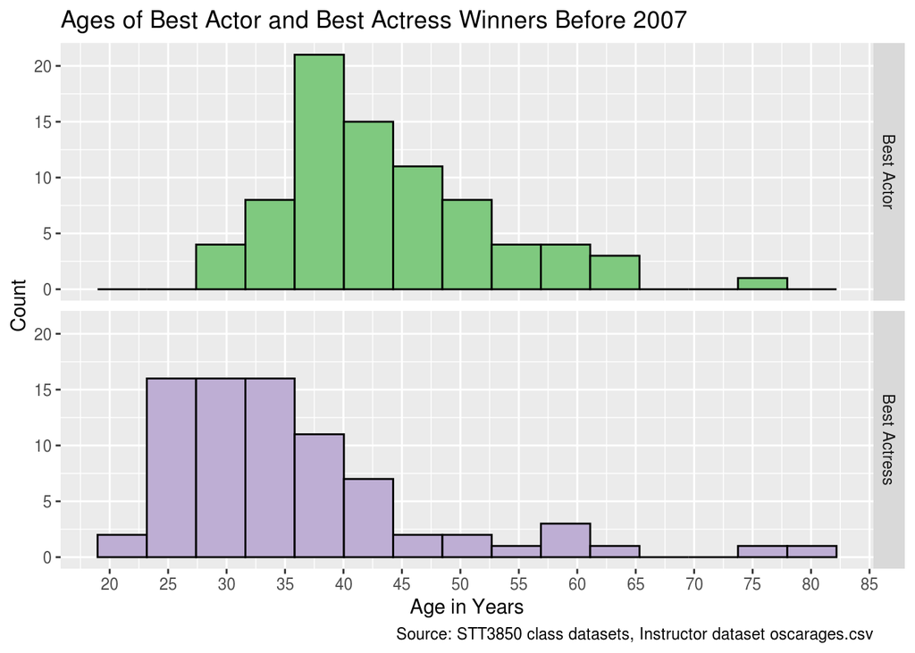

```r
ggplot(oscarpre2007, aes(x = age, fill = category)) +
  geom_histogram(color = "black", bins = 15) +
  theme(legend.position = "none") +
  scale_fill_brewer(palette = "Accent") +
  scale_x_continuous(breaks = seq(20, 85, 5)) +
  facet_grid(category ~ .) +
  labs(title = "Ages of Best Actor and Best Actress Winners Before 2007",
       x = "Age in Years",
       y = "Count",
       caption = "Source: STT3850 class datasets, Instructor dataset oscarages.csv")
```

**Bonus plots! Comparitive Densities**

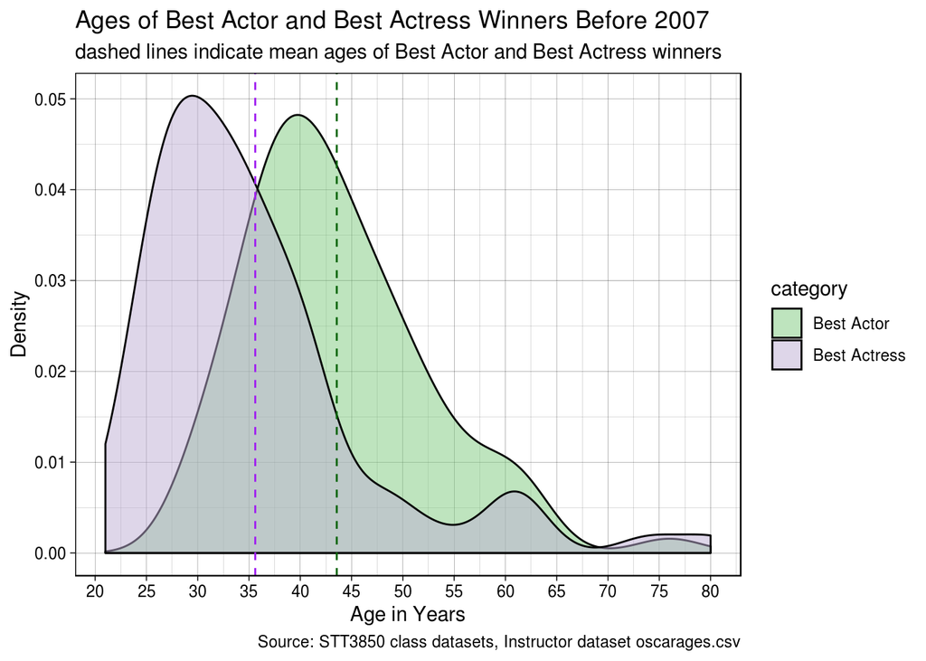

```r
ggplot(oscarpre2007, aes(x = age, fill = category)) +
  geom_density(alpha = 0.5) +
  scale_fill_brewer(palette = "Accent") +
  scale_x_continuous(breaks = seq(20, 85, 5)) +
  labs(title = "Ages of Best Actor and Best Actress Winners Before 2007",
       subtitle = "dashed lines indicate mean ages of Best Actor and Best Actress winners",
       x = "Age in Years",
       y = "Density",
       caption = "Source: STT3850 class datasets, Instructor dataset oscarages.csv") +
  geom_vline(xintercept = agesumms$meanAge, linetype = "dashed", color = c("darkgreen", "purple")) +
  theme_linedraw()
```

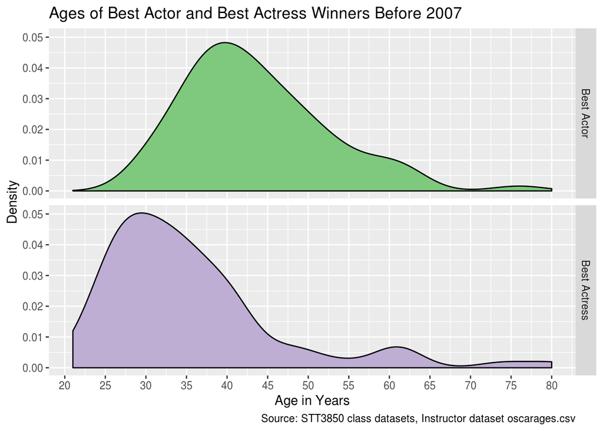

```r
ggplot(oscarpre2007, aes(x = age, fill = category)) +
  geom_density() +
  theme(legend.position = "none") +
  scale_fill_brewer(palette = "Accent") +
  scale_x_continuous(breaks = seq(20, 85, 5)) +
  facet_grid(category ~ .) +
  labs(title = "Ages of Best Actor and Best Actress Winners Before 2007",
       x = "Age in Years",
       y = "Density",
       caption = "Source: STT3850 class datasets, Instructor dataset oscarages.csv")
```

6. Which actress actually won the Best Actress Oscar in 2007? How old was she? For what movie did she win? Use the `filter` and `select` functions to display the answer. You’ll need to go back to the full dataset for this.

```r
(actresswinner2007 <- oscar %>%
  filter(ceremony == 2007, category == "Best Actress") %>%
  select(name, age, title))
```

```
# A tibble: 1 x 3
  name           age title
  <chr>        <dbl> <chr>
1 Helen Mirren    61 The Queen
```

7. Was the 2007 Best Actress winner an outlier compared to previous Best Actress winners? If she were a man, would she have been an outlier compared to previous Best Actor winners? Determine the answers using code.

How you go about answering this question depends in part on how you plan to use the output. Below are some options. All of the methods shown use the summaries you created earlier and some type of logical test. You should avoid typing values by hand (e.g., the fence values) into your code.

```r
actresswinner2007$age > agesumms$uppFence
```

```
[1] FALSE  TRUE
```

```r
ifelse(actresswinner2007$age > agesumms$uppFence, "Outlier", "Not an Outlier")
```

```
[1] "Not an Outlier" "Outlier"
```

```r
agesumms %>% select(category, uppFence) %>%
  mutate(IsHelenMirrenAnOutlier = actresswinner2007$age > uppFence)
```

```
# A tibble: 2 x 3
  category     uppFence IsHelenMirrenAnOutlier
  <chr>           <dbl> <lgl>
1 Best Actor       65.8 FALSE
2 Best Actress     54.8 TRUE
```

```r
agesumms %>% select(category, uppFence) %>%
  mutate(IsHelenMirrenAnOutlier = ifelse(actresswinner2007$age > uppFence, "Yes", "No"))
```

```
# A tibble: 2 x 3
  category     uppFence IsHelenMirrenAnOutlier
  <chr>           <dbl> <chr>
1 Best Actor       65.8 No
2 Best Actress     54.8 Yes
```

8. The 2007 article made several other statements. For example (1) For the last 10 years, the Academy hasn’t awarded a Best Actress Oscar to anyone over 39; (2) For the past nine years, that age limit has hovered even lower, at 35; (3) In fact, if one of our cover subjects wins next month, she’ll become the most mature recipient since 1990, when Jessica Tandy took home the gold for *Driving Miss Daisy*; (4) Since then, only one actress over 50 has won the supporting category, and that was Densch herself, for *Shakespeare in Love* in ’99. Can you verify these statements using code? What are the corresponding values for the Best Actor and Best Supporting Actor categories?

For the first question, “the last 10 years” would be the 1997 through 2006 ceremonies. We can filter the data in a couple different ways to get the Best Actress winners from those years. A similar logic would apply for the past nine years, or since 1990.

1. For the last 10 years, the Academy hasn’t awarded a Best Actress Oscar to anyone over 39.

```r
oscar %>%
  filter(ceremony >= 1997, ceremony <= 2006, category == "Best Actress") %>%
  summarize(oldest_winner = max(age))
```

```
# A tibble: 1 x 1
  oldest_winner
          <dbl>
1            39
```

```r
oscar %>%
  filter(ceremony %in% 1997:2006, category == "Best Actress") %>%
  arrange(desc(age))
```

```
# A tibble: 10 x 6
   ceremony decade category     name                age title
      <dbl> <chr>  <chr>        <chr>             <dbl> <chr>
 1     1997 1990s  Best Actress Frances McDormand    39 Fargo
 2     2002 2000s  Best Actress Halle Berry          35 Monster's Ball
 3     2003 2000s  Best Actress Nicole Kidman        35 The Hours
 4     1998 1990s  Best Actress Helen Hunt           34 As Good as It Gets
 5     2001 2000s  Best Actress Julia Roberts        33 Erin Brockovich
 6     2005 2000s  Best Actress Hilary Swank         30 Million Dollar Baby
 7     2006 2000s  Best Actress Reese Witherspoon    29 Walk the Line
 8     2004 2000s  Best Actress Charlize Theron      28 Monster
 9     1999 1990s  Best Actress Gwyneth Paltrow      26 Shakespeare in Love
10     2000 2000s  Best Actress Hilary Swank         25 Boys Don't Cry
```

2. For the past nine years, that age limit has hovered even lower, at 35.

```r
oscar %>%
  filter(ceremony %in% 1998:2006, category == "Best Actress") %>%
  summarize(oldest_winner = max(age))
```

```
# A tibble: 1 x 1
  oldest_winner
          <dbl>
1            35
```

3. In fact, if one of our cover subjects wins next month, she’ll become the most mature recipient since 1990, when Jessica Tandy took home the gold for *Driving Miss Daisy*. (According to the first page of the article, Meryl Streep was 57 years old, Judy Densch was 72, and Helen Mirren was 61 at the time.)

```r
oscar %>%
  filter(ceremony %in% 1990:2006, category == "Best Actress", age > 57)
```

```
# A tibble: 1 x 6
  ceremony decade category     name            age title
     <dbl> <chr>  <chr>        <chr>         <dbl> <chr>
1     1990 1990s  Best Actress Jessica Tandy    80 Driving Miss Daisy
```

```r
oscar %>%
  filter(ceremony %in% 1990:2006, category == "Best Actress") %>%
  arrange(desc(age))
```

```
# A tibble: 17 x 6
   ceremony decade category     name                age title
      <dbl> <chr>  <chr>        <chr>             <dbl> <chr>
 1     1990 1990s  Best Actress Jessica Tandy        80 Driving Miss Daisy
 2     1996 1990s  Best Actress Susan Sarandon       49 Dead Man Walking
 3     1995 1990s  Best Actress Jessica Lange        45 Blue Sky
 4     1991 1990s  Best Actress Kathy Bates          42 Misery
 5     1997 1990s  Best Actress Frances McDormand    39 Fargo
 6     1994 1990s  Best Actress Holly Hunter         36 The Piano
 7     2002 2000s  Best Actress Halle Berry          35 Monster's Ball
 8     2003 2000s  Best Actress Nicole Kidman        35 The Hours
 9     1998 1990s  Best Actress Helen Hunt           34 As Good as It Gets
10     1993 1990s  Best Actress Emma Thompson        33 Howard's End
11     2001 2000s  Best Actress Julia Roberts        33 Erin Brockovich
12     2005 2000s  Best Actress Hilary Swank         30 Million Dollar Baby
13     1992 1990s  Best Actress Jodie Foster         29 The Silence of the Lambs
14     2006 2000s  Best Actress Reese Witherspoon    29 Walk the Line
15     2004 2000s  Best Actress Charlize Theron      28 Monster
16     1999 1990s  Best Actress Gwyneth Paltrow      26 Shakespeare in Love
17     2000 2000s  Best Actress Hilary Swank         25 Boys Don't Cry
```

4. Since then, only one actress over 50 has won the supporting category, and that was Densch herself, for *Shakespeare in Love* in ’99.

```r
oscar %>%
  filter(ceremony %in% 1990:2006, category == "Supporting Actress", age > 50)
```

```
# A tibble: 1 x 6
  ceremony decade category           name         age title
     <dbl> <chr>  <chr>              <chr>      <dbl> <chr>
1     1999 1990s  Supporting Actress Judi Dench    64 Shakespeare in Love
```

For the Best Actors and Supporting Actors…

1. How many Best Actors were older than 39 in the last 10 years? Who is the oldest?

```r
oscar %>%
  filter(ceremony >= 1997, ceremony <= 2006, category == "Best Actor") %>%
  summarize(oldest_winner = max(age))
```

```
# A tibble: 1 x 1
  oldest_winner
          <dbl>
1            60
```

```r
oscar %>%
  filter(ceremony %in% 1997:2006, category == "Best Actor") %>%
  arrange(desc(age))
```

```
# A tibble: 10 x 6
   ceremony decade category   name                     age title
      <dbl> <chr>  <chr>      <chr>                  <dbl> <chr>
 1     1998 1990s  Best Actor Jack Nicholson            60 As Good as It Gets
 2     2002 2000s  Best Actor Denzel Washington         47 Training Day
 3     1999 1990s  Best Actor Roberto Benigni           46 Life Is Beautiful
 4     1997 1990s  Best Actor Geoffrey Rush             45 Shine
 5     2004 2000s  Best Actor Sean Penn                 43 Mystic River
 6     2000 2000s  Best Actor Kevin Spacey              40 American Beauty
 7     2006 2000s  Best Actor Philip Seymour Hoffman    38 Capote
 8     2005 2000s  Best Actor Jamie Foxx                37 Ray
 9     2001 2000s  Best Actor Russell Crowe             36 Gladiator
10     2003 2000s  Best Actor Adrien Brody              29 The Pianist
```

```r
oscar %>%
  filter(ceremony >= 1997, ceremony <= 2006, category == "Best Actor") %>%
  summarize(fraction_39_or_under = mean(age > 39))
```

```
# A tibble: 1 x 1
  fraction_39_or_under
                 <dbl>
1                  0.6
```

```r
oscar %>%
  filter(ceremony %in% 1998:2006, category == "Best Actor") %>%
  summarize(oldest_winner = max(age))
```

```
# A tibble: 1 x 1
  oldest_winner
          <dbl>
1            60
```

```r
oscar %>%
  filter(ceremony >= 1997, ceremony <= 2006, category == "Best Actor") %>%
  summarize(fraction_35_or_under = mean(age > 35))
```

```
# A tibble: 1 x 1
  fraction_35_or_under
                 <dbl>
1                  0.9
```

3. How many Best Actors since 1990 are older than the three Best Actress nominees?

```r
oscar %>%
  filter(ceremony %in% 1990:2006, category == "Best Actor") %>%
  arrange(desc(age))
```

```
# A tibble: 17 x 6
   ceremony decade category   name                    age title
      <dbl> <chr>  <chr>      <chr>                 <dbl> <chr>
 1     1998 1990s  Best Actor Jack Nicholson           60 As Good as It Gets
 2     1992 1990s  Best Actor Anthony Hopkins          54 The Silence of the La…
 3     1993 1990s  Best Actor Al Pacino                52 Scent of a Woman
 4     2002 2000s  Best Actor Denzel Washington        47 Training Day
 5     1999 1990s  Best Actor Roberto Benigni          46 Life Is Beautiful
 6     1997 1990s  Best Actor Geoffrey Rush            45 Shine
 7     1991 1990s  Best Actor Jeremy Irons             43 Reversal of Fortune
 8     2004 2000s  Best Actor Sean Penn                43 Mystic River
 9     2000 2000s  Best Actor Kevin Spacey             40 American Beauty
10     1995 1990s  Best Actor Tom Hanks                38 Forrest Gump
11     2006 2000s  Best Actor Philip Seymour Hoffm…    38 Capote
12     1994 1990s  Best Actor Tom Hanks                37 Philadelphia
13     2005 2000s  Best Actor Jamie Foxx               37 Ray
14     2001 2000s  Best Actor Russell Crowe            36 Gladiator
15     1990 1990s  Best Actor Daniel Day-Lewis         32 My Left Foot
16     1996 1990s  Best Actor Nicolas Cage             32 Leaving Las Vegas
17     2003 2000s  Best Actor Adrien Brody             29 The Pianist
```

```r
oscar %>%
  filter(ceremony %in% 1990:2006, category == "Best Actor", age > 57)
```

```
# A tibble: 1 x 6
  ceremony decade category   name             age title
     <dbl> <chr>  <chr>      <chr>          <dbl> <chr>
1     1998 1990s  Best Actor Jack Nicholson    60 As Good as It Gets
```

```r
oscar %>%
  filter(ceremony %in% 1990:2006, category == "Best Actor", age > 61)
```

```
# A tibble: 0 x 6
# … with 6 variables: ceremony <dbl>, decade <chr>, category <chr>, name <chr>,
#   age <dbl>, title <chr>
```

```r
oscar %>%
  filter(ceremony %in% 1990:2006, category == "Best Actor", age > 72)
```

```
# A tibble: 0 x 6
# … with 6 variables: ceremony <dbl>, decade <chr>, category <chr>, name <chr>,
#   age <dbl>, title <chr>
```

4. How many supporting actors since 1990 have been over 50?

```r
oscar %>%
  filter(ceremony %in% 1990:2006, category == "Supporting Actor", age > 50) %>%
  arrange(desc(age))
```

```
# A tibble: 8 x 6
  ceremony decade category         name             age title
     <dbl> <chr>  <chr>            <chr>          <dbl> <chr>
1     1992 1990s  Supporting Actor Jack Palance      73 City Slickers
2     1999 1990s  Supporting Actor James Coburn      70 Affliction
3     2000 2000s  Supporting Actor Michael Caine     67 The Cider House Rules
4     2005 2000s  Supporting Actor Morgan Freeman    67 Million Dollar Baby
5     1995 1990s  Supporting Actor Martin Landau     66 Ed Wood
6     1993 1990s  Supporting Actor Gene Hackman      63 Unforgiven
7     2002 2000s  Supporting Actor Jim Broadbent     52 Iris
8     2003 2000s  Supporting Actor Chris Cooper      51 Adaption
```

```r
oscar %>%
  filter(ceremony %in% 1990:2006, category == "Supporting Actor") %>%
  summarize(fraction_over_50 = mean(age > 50))
```

```
# A tibble: 1 x 1
  fraction_over_50
             <dbl>
1            0.471
```